# EXAM PT 2

Scott Robbins

2025-03-14

# Question 1

```
## # A tibble: 6 × 5
##    pm25  fips region longitude latitude
##   <dbl> <dbl> <chr>      <dbl>    <dbl>
## 1 10.8   1069 east       -85.4     31.2
## 2 11.6   1073 east       -86.8     33.5
## 3 11.3   1089 east       -86.6     34.7
## 4  9.41  1097 east       -88.1     30.7
## 5 11.4   1103 east       -86.9     34.5
## 6 12.4   1113 east       -85.1     32.4
```

# Question2

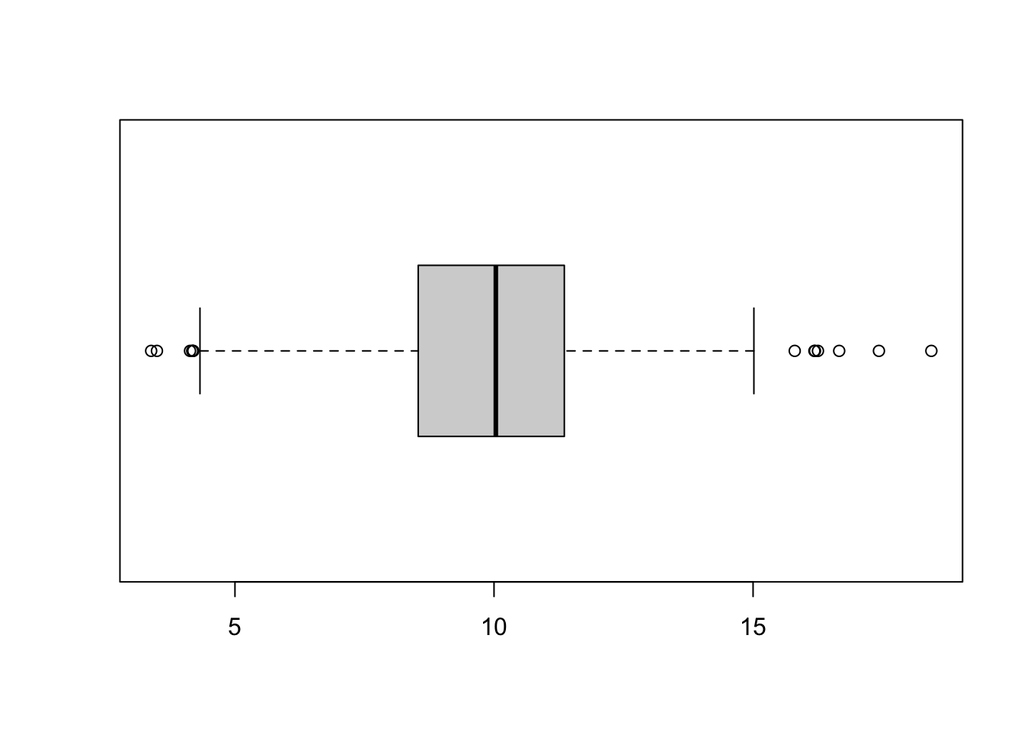

The data appears to be symmetric, with multiple outliers on the low and high side.

# Question3

```
## # A tibble: 8 × 5
##    pm25  fips region longitude latitude
##   <dbl> <dbl> <chr>      <dbl>    <dbl>
## 1  16.2  6019 west       -120.     36.6
## 2  15.8  6029 west       -119.     35.3
## 3  18.4  6031 west       -120.     36.2
## 4  16.7  6037 west       -118.     34.1
## 5  15.0  6047 west       -121.     37.2
## 6  17.4  6065 west       -117.     33.8
## 7  16.3  6099 west       -121.     37.6
## 8  16.2  6107 west       -119.     36.2
```

All of these Counties are in the western region

# Question 4

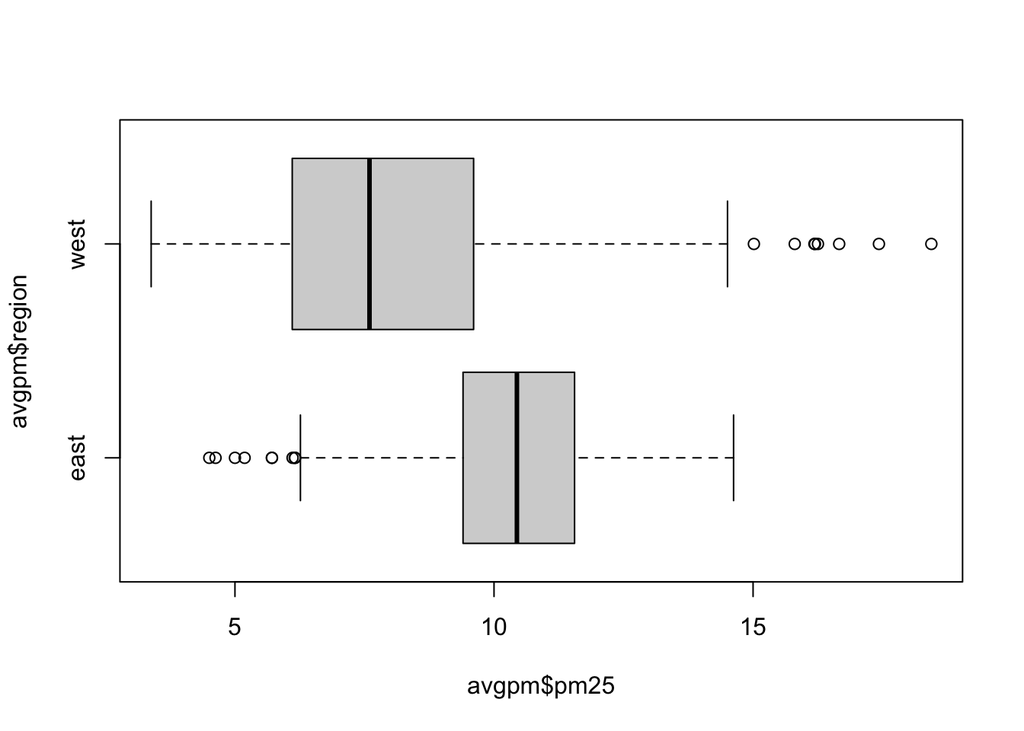

Generally, counties in the Western region have lower pollution levels than counties in the Eastern region, seeing as the median is lower, the minimum value is lower, and the IQR is almost completely lower in the West. The Western region only has high outliers, while the Eastern region only has low outliers.

# Question 5

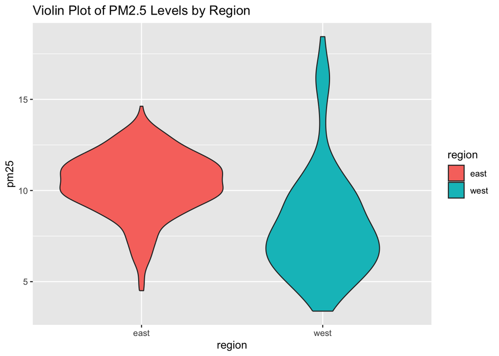

The East region has a relatively compact distribution with most values concentrated around 10, and fewer extreme values. The West region has a wider spread, with some counties having significantly lower pollution levels but also a notable tail extending past 15, meaning higher pollution in some areas.

# Question 6

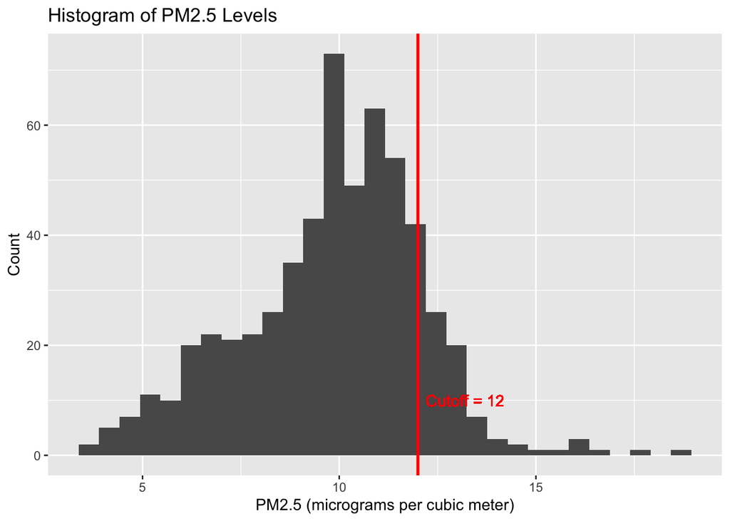

The graph seems to be close to a normal distribution. There are many counties who have a PM2.5 level higher than 12, with a maximum value at about 18.

# Quesiton 7

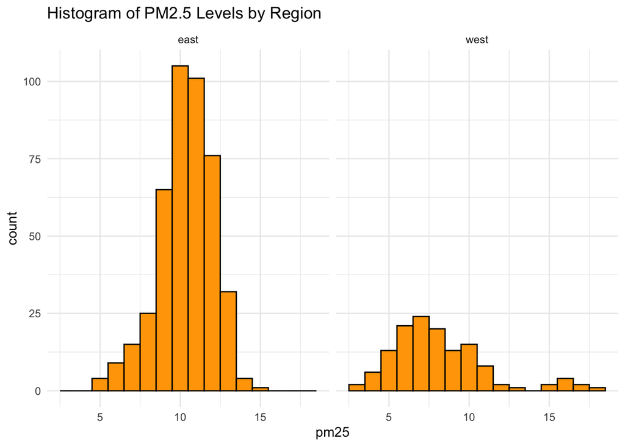

The East region’s distribution is approximately bell shaped, which means the distribution is normal with the center at about 10. The West region’s distribution is bimodal, with two subgroups. The first supgroup has a center of about 7-8, while the second has a center of about 16.

# Question 8

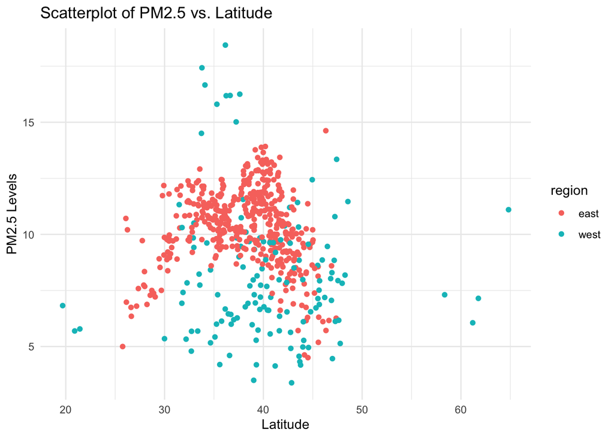

# Question 9

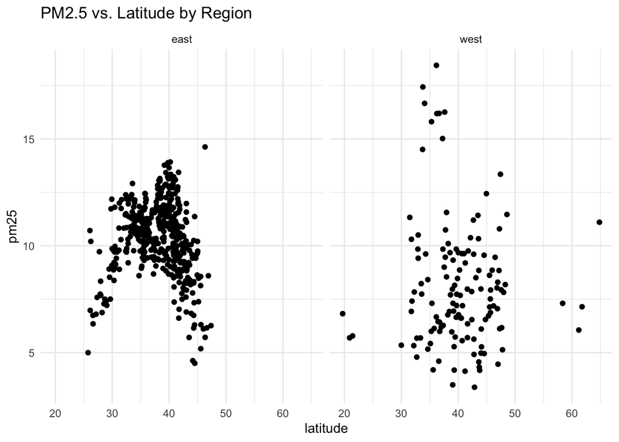

# Question 10

[output not shown]

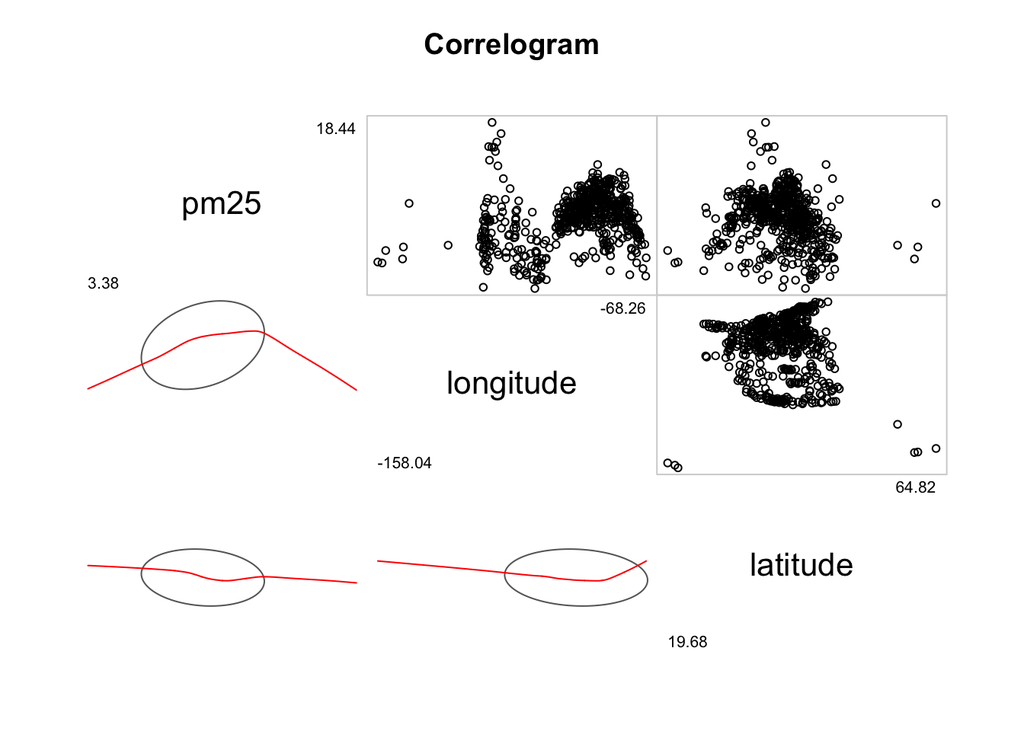

The PM2.5 vs. latitude plot suggests some clustering, meaning PM2.5 levels might vary significantly across different latitudes. The PM2.5 vs. longitude plot also shows clustering, meaning that PM2.5 levels might be dependant on the region PM2.5 vs. longitude: The slightly slanted ellipse suggests a weak nonlinear relationship. PM2.5 vs. latitude: The elliptical shape is nearly flat, implying a very weak or no correlation between PM2.5 and latitude. Latitude vs. longitude: The near-horizontal red line suggests almost no relationship between latitude and longitude in this dataset. The weak correlation between PM2.5 and latitude and longitude suggests that other factors are influencing the PM2.5 levels, other than just location and region.